# Introduction to Gradients

**Note**: This notebook is illustrative only and cannot be run. For an interactive version, please visit the [Colab Notebook](https://colab.research.google.com/drive/12TUUciM9D8yqv2yKXDqcUV8YfzcuTHaq?usp=sharing)

## I. The Derivative

In calculus, the derivative of a function $f(x)$ at point $x$ is represented as $\frac{df}{dx}$, and can be thought of as the change in $f$ resulting from a miniscule change in $x$

For example, consider the function,

$f(x) = 2x^2$

The derivative of this function is given as,

$f'(x) = 4x$

When $x = 3$, $f(3) = 2(3)^2 = 18$. However, the rate of change of the function at $f(3)$ is $f'(3) = 4(3) = 12$. The $x^2$ term in $f(x)$ tells us that the function is quadratic, while the lack of exponent in $f'(x)$ tells us that the derivative is linear. This is illustrated by the graph below.

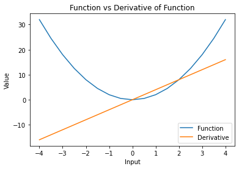

```python
func = lambda x: 2*x**2
derivative = lambda x: 4*x

smp.plot_derivative(func, derivative)
```

## II. The Gradient

A **gradient** is analogous to the derivative for *scalar-valued multivariable functions*. In particular, the gradient of a function $f(x_1, x_2, ...):\mathbb R^n\,\to\,\mathbb R$ is denoted as $\nabla f:\mathbb R^n\,\to\,\mathbb R^n$ and is given as,

$\nabla f = \begin{bmatrix}\frac {\partial f}{\partial x_1} \\ \frac {\partial f}{\partial x_2} \\ \vdots \end{bmatrix}$

Where $\frac {\partial f}{\partial x_i}$ is the **partial derivative** of $f$ with respect to $x_i$.  
($\nabla$ is the inverted greek letter delta, and is called "nabla"; $\partial$ is the symbol "del")  
If all this seems too abstract, don't worry. We'll go through an example to make it more concrete.

Consider the function,

$f(x,y) = -2x^2 -x^2y^2$

The function is plotted below.

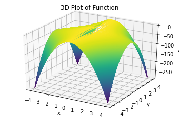

```python
f = lambda x,y: -2*x**2 - x**2*y**2
smp.plot_3d(f)
```

The partial derivative is fundamentally similar to the derivative, in that $\frac {\partial f} {\partial x}$ represents the the change in $f$ resulting from a miniscule change in $x$, except now we do this while *holding everything else constant*.  
Computing the partial derivatives for the example function, we have:

$\frac {\partial f} {\partial x}(x,y) = -4x - 2xy^2$

$\frac {\partial f} {\partial y}(x,y) = -2x^2y$

We can now use these functions to calculate the instantaneous rate of change with respect to each variable at any given point. For example, at $(2,1)$,

$\frac {\partial f} {\partial x}(2,1) = -4(2) - 2(2)(1)^2 = -12$

$\frac {\partial f} {\partial y}(2,1) = -2(2)^2(1) = -8$

The rate of change of $f$ at $(2,1)$ with respect to $x$ and $y$ is $-12$ and $-8$, respectively.  
Now that we have computed all the partial derivatives, we can supply the gradient of $f$,

$\nabla f(x,y) = \begin{bmatrix}-4x - 2xy^2 \\ -2x^2y \end{bmatrix}$

From the example above, we know that,

$\nabla f(2,1) = \begin{bmatrix}-12 \\ -8 \end{bmatrix}$

But what does this tell us, exactly? Think of the surface plotted above as a hill on which you are walking. The slope of the hill depends on where you are and which direction you are walking. For example, your climb up would be a lot steeper if you were standing on the purple part of the hill as opposed to the yellow part.

Remember that the gradient is a vector, and vectors have magnitude and direction. At a given point $(x,y)$, the gradient $\nabla f(x,y)$ is a vector which *points in the direction of steepest ascent* with *magnitude indicating the slope of the hill* in that direction.

```python
grad_f = lambda x,y: np.array([-4*x - 2*x*y**2, -2*x**2*y])
print('Gradient of f at ({},{}): {}'.format(2,1,grad_f(2,1)))
```

```
Gradient of f at (2,1): [-12  -8]
```

Visual inspection of the surface plot tells us that $f$ attains a maximum value of $0$ at $(0,y)$. We can use our gradient to inform us of this as well; notice how $\nabla f(2,1) = \begin{bmatrix}-12 \\ -8 \end{bmatrix}$ informs us to move in the negative direction to ascend. Let's see what happens as we move towards the origin:

```python
template = 'point: ({},{}), gradient: {}, f: {}'
print(template.format(1,1,grad_f(1,1),f(1,1)))
print(template.format(1,0,grad_f(1,0),f(1,0)))
print(template.format(0,0,grad_f(0,0),f(0,0)))
print(template.format(-1,-1,grad_f(-1,-1),f(-1,-1)))
```

```
point: (1,1), gradient: [-6 -2], f: -3
point: (1,0), gradient: [-4  0], f: -2
point: (0,0), gradient: [0 0], f: 0
point: (-1,-1), gradient: [6 2], f: -3
```

Note that as we move closer to the origin, the magnitude of the gradient decreases; this phenomenon agrees with our plot illustrating that the hill is getting less steep. At $(0,0)$, one point where $f$ attains its maximum value, the gradient is the zero vector. You should recognize this phenomenon from single-variable calculus, where local maxima and minima are computed by setting the derivative of the function equal to zero and solving for $x$. In fact, for this function, the maximum value is not only attained at the origin, but across all points on the line $x = 0$:

$\nabla f(0,y) = \begin{bmatrix}-4(0) - 2(0)y^2 \\ -2(0)^2y \end{bmatrix} = \begin{bmatrix}0 \\ 0 \end{bmatrix}$

Finally, notice that as we move past the origin and select negative values for $x$ and $y$, the gradient vector has positive values, orienting us back in the direction of the origin.  
This phenomemon can be better illustrated with a vector field:

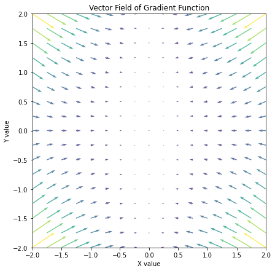

```python
smp.plot_vectorfield(grad_f)
```

This vector field plots the gradient vector across a grid of points, with lighter colors denoting vectors with higher magnitudes. Notice that, for all points where $x = 0$, the gradient vector is the zero vector.

Recall that, in performing gradient computations for $f$ with python, we calculated $\nabla f$ by hand and used it to define `grad_f`. However, computing the gradient by hand is time consuming and difficult, if not impossible, for complicated functions. Luckily, in practice the gradient is never computed manually. Instead, we can employ the automatic differentiation package `autograd`.

```python
from autograd import grad, value_and_grad

#grad computes the gradient function of an input function. the tuple parameter dictates which partials you would like computed
grad_f = grad(f,(0,1))

#use the output function from the previous line to compute gradient.
#Floats are used as input because autograd cannot differentiate wrt integers
print('Gradient of f at ({},{}): {}'.format(2,1,grad_f(2.,1.)))
```

```
Gradient of f at (2,1): (array(-12.), array(-8.))
```

Notice how we were able to attain the value of $\nabla f(2,1)$ while only specifying $f$. That's the beauty of `autograd`.

## III. The Gradient Descent Optimizer

In machine learning, we teach machines by building a *loss function*, which is a function that takes the parameters we are trying to learn as input and outputs the magnitude of the error of the prediction resulting from those parameters. When we optimize with respect to this function, we find the input parameter that minimizes the loss or error, which is our goal.  
As an example, suppose I was thinking of the number 5, and you were trying to guess the number in my head. Everytime you guessed a number $x$, I would report to you how inaccurate your guess was by computing $l(x) = |5-x|$ and returning the result to you. After you receive every error, you will know which direction to guess in. If your first guess is $x = 7$ and I tell you $l(7) = 2$ and your second guess is $x = 8$ and I tell you $l(8) = 3$, you will realize you are guessing in the wrong direction and move in the correct direction. You will keep repeating this process until you guess $x = 5$, at which point I will report a loss $l(5) = 0$, and you will know that you have completed the task, because you have attained the lowest possible error for this exercise. At this point, you will report your guess to me, and it will be correct.  
Similarly, in machine learning we continue to make guesses for the optimal values of the parameters; however, rather than guessing randomly, we do so in a systematic way that employs the gradient.  
Our goal is to minimize the value of the loss function. Recall that the gradient of a function $f$ at a point $\vec w_0$ points in the direction of steepest ascent. Thus, $-\nabla f(\vec w_0)$ points in the direction of steepest descent. By calculating the negative gradient, and adding it to the current point $\vec w_0$, we obtain a new point $\vec w_1$. We can continue to repeat this process as many times as we'd like to get closer and closer to the point $\vec {w^*}$ that minimizes $f$. Note that in practice, we will never find $\vec {w^*}$, but finding the very best point is usually not necessary; we just have to come close. This is the basis of the gradient descent algorithm.

**Algorithm: Gradient Descent**  
Input: loss function $f:\mathbb R^n \rightarrow \mathbb R$, initial point $\vec w_0 \in \mathbb R^n$, learning rate $\alpha > 0$, number of iterations *max_it* $> 0$  
Output: best parameter recovered $\vec w \in \mathbb R^n$

1. Let $\vec w = \vec w_0$
2. Repeat for *max_it* times:  
   a. Compute $\vec g = \nabla f(\vec w)$  
   b. Compute $\vec g_n = \frac{\vec g}{||\vec g||}$  
   c. Update $\vec w = \vec w - \alpha*\vec g_n$
3. Return $\vec w$

□  
Notes:  
2a. Here we are computing the gradient vector with respect to our current $\vec w$  
2b. The gradient vector has both magnitude and direction. We are only interested in preserving the direction of ascent, so we store normalized $\vec g$, which now has magnitude $1$, as $\vec g_n$  
2c. Finally, we multiply $\vec g_n$ by $\alpha$. The latter parameter allows us to dictate the magnitude of the gradient vector, thereby governing how rapidly $\vec w$ is updated, a.k.a. the rate of "learning" of the algorithm. We take this resultant vector and negate it to find the direction of steepest descent, then add it to $\vec w$ to obtain our updated $\vec w$. The process is then repeated.

```python
def gradient_descent(f, X, y, w_0, alpha, max_its):
    """gradient descent optimizer. Returns argument that minimizes f"""

    #Verify input constraints met
    assert alpha > 0
    assert max_its > 0

    #use autograd's grad function to compute gradient function of f
    f_grad = value_and_grad(f)

    cost_hist = []

    #Step 1.
    vec_w = w_0

    #Step 2.
    for i in range(1,max_its+1):

        #Step 2a.
        cost_w,vec_g = f_grad(vec_w,X,y)
        #We are also collecting and appending cost (loss) at each gradient evaluation
        #This is for illustration purposes only and not necessary for the algorithm
        cost_hist.append(cost_w)

        #Step 2b.
        vec_gn = vec_g/np.linalg.norm(vec_g)

        #Step 2c.
        vec_w = vec_w - alpha*vec_gn
        #or for adaptive learning rate (see below):
        #vec_w = vec_w - (alpha/i)*vec_gn

    #Step 3
    return vec_w,cost_hist
```

Let's employ gradient descent to solve a toy linear regression problem. Below, a sample of points is generated based off the line $y = 2x + 1$. Error is added to the values to simulate the noise found in real world data. The points along with the underlying relationship are plotted below.

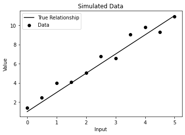

```python
#create ground truth relationship (this is what we are trying to learn)
linear_function = lambda x: 2*x + 1

x_vals = np.linspace(0,5,11)
#random noise to mimic real world data
noise = np.random.normal(scale=0.9,size=len(x_vals))
y_vals = linear_function(x_vals) + noise

smp.pred_reg_plot(x_vals,y_vals,linear_function)
```

In order to predict a relationship with the given data, we need to develop a loss function. For a linear regression, a *line of best fit* is the line $f(X) = mX + b$ that minimizes the average vertical distance across all points. We can calculate the distance between a true value, $(x_i, y_i)$ and its prediction $(x_i, f(x_i))$ as,

$|mx_i + b - y_i| = |f(x_i) - y_i|$

For $x_i$ and $y_i$ in feature and label sets $X$ and $y$, respectively. We can sum this operation across all $n$ points, and then divide by $n$ to retrieve the average distance,

$\frac{1}{n}\sum_{i=1}^{n} |f(x_i) - y_i|$

In practice, instead of taking the absolute value of the difference, we instead take the square of the difference. The reason for this is that a squared function is differentiable everywhere, while an absolute function is not. Continuous differentiability is a requirement for a function to have a derivative or gradient that exists everywhere. Thus, we have,

$\frac{1}{n}\sum_{i=1}^{n} (f(x_i) - y_i)^2$

This function is known as the *least squares loss function*, and is what we will be minimizing via gradient descent to recover the optimal parameters.

The parameters we are trying to recover are the slope $m$ and intercept $b$ of the line of best fit $f$. However, we can rewrite $f$ with vectors as,

$f(X) = mX + b = \begin{bmatrix}b & m \end{bmatrix} \begin{bmatrix}1 \\ X \end{bmatrix} = \vec w^T \begin{bmatrix}1 \\ X \end{bmatrix}$

Where the first element in $\vec w$ represents the intercept and the second the slope. In practice, we vectorize operations because computers can do these types of computations more quickly. However, notice that to do this, we need to preprocess the input features ($X$ values) by placing them into a vector and stacking a $1$ on top. This is done so that the intercept value is left unchanged after the multiplication of the vectors. An efficient implementation of this is shown below.

```python
def preprocess_input(x_vals):
    #get vector of with length equivalent to number of points in X
    o = np.ones((1,np.shape(x_vals)[0]))
    #stack ones on top of x values and take transpose to retrieve preprocessed inputs
    X = np.vstack((o,x_vals)).T
    return X
```

Now that the input has been preprocessed, we can implement a vectorized least squares loss function, which we now define as,

$l(X,y) = \frac{1}{n}\sum_{i=1}^{n} (\vec w^T \begin{bmatrix}1 \\ x_i \end{bmatrix} - y_i)^2$

```python
def least_squares(w,X,y):
    cost = np.sum((np.dot(X,w) - y)**2)
    return cost/float(len(y))
```

Finally now we are ready to use gradient descent to predict the trend of these points. Below we call the gradient descent function and pass it our data, and an initial parameter vector, which is randomly initialized. We also pass it a loss function, learning rate, and number of iterations. These last three attributes are known as **hyperparameters**; that is, they are *parameters that govern how well the algorithm is able to learn the parameter of interest*, in this case $\vec w$.

```python
X,y = preprocess_input(x_vals),y_vals
alpha = 0.01
max_it = 250
#initialize random vector as first guess
w_0 = np.random.random(size=2)

best_w, cost_hist = gradient_descent(least_squares,X, y, w_0, alpha, max_it)
```

```python
print('recovered prediction of parameter: {}'.format(np.round(best_w,2)))
```

```
recovered prediction of parameter: [1.4  1.94]
```

Remember that in our example, the true parameter value was $\begin{bmatrix}1 \\ 2 \end{bmatrix}$, since the underlying line from which we generated points was $y = 2x + 1$. This is a fairly accurate, but not perfect estimation. However, this is expected given that noise was added to the data. Below the line formed by the estimated parameter is plotted alongside the underlying line and original data.

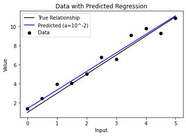

```python
smp.pred_reg_plot(x_vals,y_vals,linear_function,[best_w])
```

Recall that in the gradient descent code we also retrieved and stored the cost value obtained at each update of $\vec w$. By plotting these cost values over time, we can see how well the algorithm learned from the data:

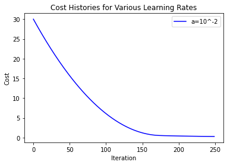

```python
smp.plot_cost_hists([cost_hist],['a=10^-2'])
```

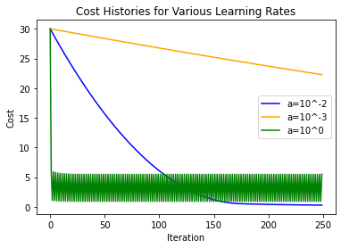

```python
w_1, cost_hist_1 = gradient_descent(least_squares, X, y, w_0, 0.001, max_it)
w_2, cost_hist_2 = gradient_descent(least_squares, X, y, w_0, 1, max_it)

smp.plot_cost_hists([cost_hist, cost_hist_1, cost_hist_2],['a=10^-2','a=10^-3','a=10^0'])
```

The first curve is the same one we analyzed above, and is plotted for reference.

The second curve is a cost history for the algorithm with a learning rate of $0.001$, a rate 10 times slower than that of the base curve. Though the curve shows steady decrease in cost, it is semi-linear, and does not appear to be near convergence. This is because of the fact that this algorithm is learning at a very refined, but slow rate. If we increased the number of iterations, it is likely that we would see convergence; however, this makes the algorithm more computationally expensive, and the benefits from doing this are few, as it is unlikely the converged cost of this curve will be much lower than that of the base case.  
Okay, so if a slow learning rate takes longer to converge, why not just use a very high number for the learning rate? The final curve does just this, employing a learning rate of $1$, which is 100 times faster than that of the base curve. Initially, this curve converges far more quickly than that of the base curve. However, then something interesting begins to happen that is difficult to make out from this figure. To see what's going on, let's zoom in to this curve and see what's going on:

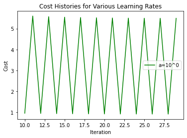

```python
smp.plot_cost_hists([cost_hist_2[10:30]],['a=10^0'],start=10,color='green')
```

The second and third curves are exact opposite cases of one another. While the slow learning rate of the second algorithm allows it to capture the fine trends in the data, it does so too slowly, thereby being unnecessarily expensive. In contrast, while a high learning rate allows for an algorithm to significantly reduce computational costs, the tradeoff is its inability to learn these granularities. The best algorithm employs a learning rate than balances these two tradeoffs. In fact, we can combine the advantages of these two by using a high learning rate initially, where the direction of the gradient doesn't change much, and then gradually reducing this value as the number of iterations increase. A simple way of doing this is to divide the learning rate by the current iteration value in the gradient descent loop (i.e. modify `alpha` to `alpha/i` in the `gradient_descent` method). This is known as an **adaptive learning rate**.

The figure below illustrates the cause of the oscillations depicted above, and shows how an algorithm utilizing an adaptive learning rate overcomes this issue.

[figure not shown]

The regressions estimated by each of the algorithms with various learning rates are plotted below, along with the data and true relationship.

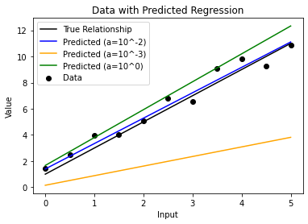

```python
smp.pred_reg_plot(x_vals,y_vals,linear_function,[best_w,w_1,w_2])
```

We can also plot the final cost of each of the regressions, along with the cost of the true relationship as a baseline. Once again, here we are defining cost via the least squares algorithm. Though it may seem counterintuitive that the cost of the optimal regression is actually lower than that of the true relationship, this is actually not surprising: the algorithm is overfitting to the noise in the limited data generated. As the size of the data increases, the effect of this phenomenon diminishes.

```python
final_cost = lambda w: least_squares(w,X,y)

print('Least squares errors of various learning rates for sample data:')
print('Ground truth: {:.2f}'.format(final_cost(np.array([1,2]))))
print('a=10^-2: {:.2f}'.format(final_cost(best_w)))
print('a=10^-3: {:.2f}'.format(final_cost(w_1)))
print('a=10^0: {:.2f}'.format(final_cost(w_2)))
```

```
Least squares errors of various learning rates for sample data:
Ground truth: 0.40
a=10^-2: 0.28
a=10^-3: 22.26
a=10^0: 0.91
```

## IV. Exercises

Consider the function,

$f(x,y) = 2x^2 - 4x + 3y^2 - 12y$

1. manually compute $\nabla f$ and express it as a `lambda` function. At what point $(x, y)$ is $\nabla f(x,y) = \vec 0$?
2. Plot the vectorfield of $f$. For the point you computed above, is $f$ at a local maximum, local minimum, or saddle point?

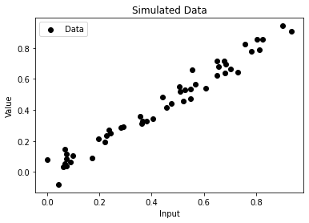

```python
data = (pd.read_csv("drive/My Drive/course_dependencies/datasets/2d_linregress_data.csv",
                    header=None,
                    names=['x_vals', 'y_vals']))

x_vals, y_vals = data['x_vals'], data['y_vals']
smp.pred_reg_plot(x_vals, y_vals)
```

1. Use the gradient descent algorithm to retrieve the best linear regression parameters for the data above. Then plot your linear regression: `smp.pred_reg_plot(x_vals, y_vals,ex=best_w)`
2. Plot your cost history. Does it looked like your model learned the data well? If so, how can you tell? If not, play with your hyperparameters until this is achieved.